# ADA and DS Tutorial

## Introductions

- Paul (ADA Instructor)
- Garth (DS Instructor)
- Gina (TA)

## Expectations for DS Week 1

- Develop a scientific question that is feasible.
  - Needs to answer a specific question.
  - Have an element of scientific study design.
  - Data collection and analysis.
- Use a conceptual model to outline the question and relate it to the study design, what factors will influence results.
- Design a Study.
- Write a Proposal.

## Expectations for ADA Week 1

- Statistical Review
  - Distributions
  - Random Variables
- Study Design
  - Experimental Design
  - Field Study Design
- Sample Size Calculations
  - Power + Precision

## Stats Experience?

1. Standard Deviation vs Standard Error
2. Confidence Interval
3. T-Test
4. ANOVA
5. Linear Model
6. Model Selection
7. GLM

## What do you want to learn?

- Bayesian Statistics
- Capture-Recapture
- Occupancy Modelling
- Multivariate Analysis
- Survival (Time Until Event) Analysis
- Time Series Analysis
- Generalized Additive Models

## Principles of Good Design

1. Keep it simple.
2. Make strong a priori prediction.
3. Control for as much as you can (temperature, flow rates, tank effects, time of year, etc.).
4. Randomize over what you can’t control.
5. Have an analysis plan.
6. Simulate what you think your outcomes will be.
7. Ensure enough replication to answer your hypothesis with confidence.
8. Plan for when things might go wrong.

## A Scientific Design

- Judgement Sampling: You get to choose sites you like.
  - They are conveniently located, near a nice hotel, or places you think are optimal to answer your hypothesis.
  - Not randomly chosen. Good for pilot studies, understanding those specific sites.
- Scientific Sampling: You get to choose a sample frame that represents the population, and randomly sample from that.
  - Robust statistical inference.
  - You will be able to understand the area as a whole.

## Importance of a Random Sample

[figure not shown]

## Importance of a Random Sample

[figure not shown]

## Scope of Inference

- What does your sample represent?
  - If you select random beaches for measuring clam abundance in Barkley Sound (The Whole Sound)
  - If you can only access 10 Beaches, and randomly select 5, (It’s those 10 beaches you can access). We just hope that accessibility doesn’t impact trend.
- Experimental Design, This is more focused on what the limitation of an experiment on what is being observed.
  - Do animals behave different in a lab?
  - Is physiology impacted by the environment where you collected the specimen?

## Sample Units

- The unit of measurement in the study.
  - Plankton tow?
  - Individuals within Plankton tow?
  - Bay with repeated sampling within?
- Experimental Unit: Unit of measurement in the experiment…
  - Tank with animals in it?
  - Animals within a tank?

## Variance

- A measure of the amount of randomness in the sample.

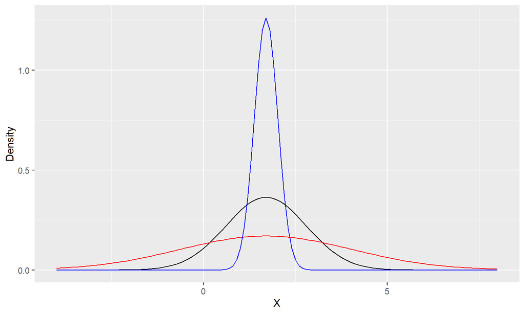

## Discuss

- Give me an example of something with very high variance that you might want to study?
- Give me an example of very low variance?
- How might you design a study to reduce the amount of variance?

## Replication (Independent Samples)

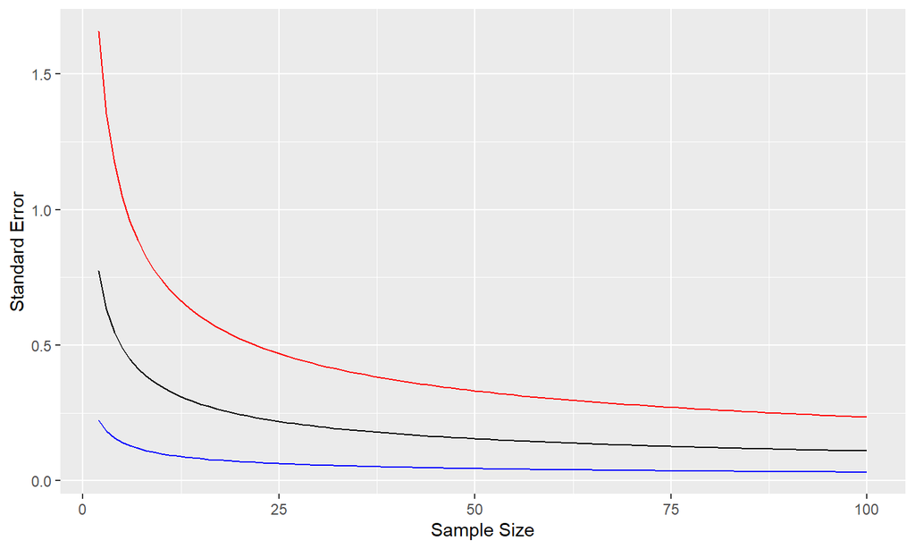

## Repeated Sampling

- Let’s assume a sample size of 10 independent individuals/sites.

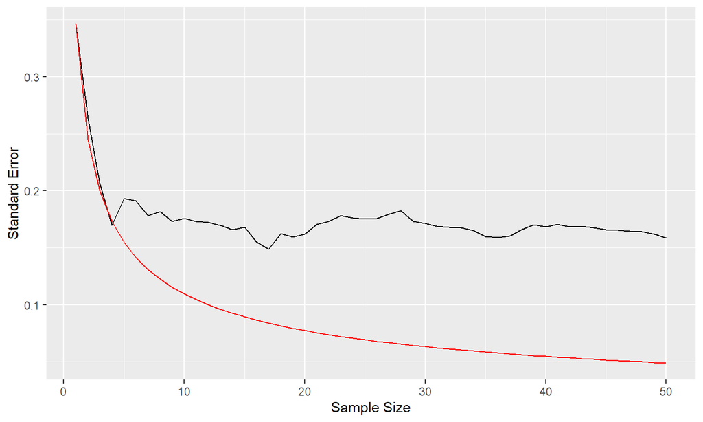

## When should we replicate vs repeat?

- Cost of getting to site is high and within site variability is high.
- No within vs between trends.
- Low between variance (nearly independent)

## High Within Variance/Low Between

- Let’s assume a sample size of 10 independent individuals/sites.

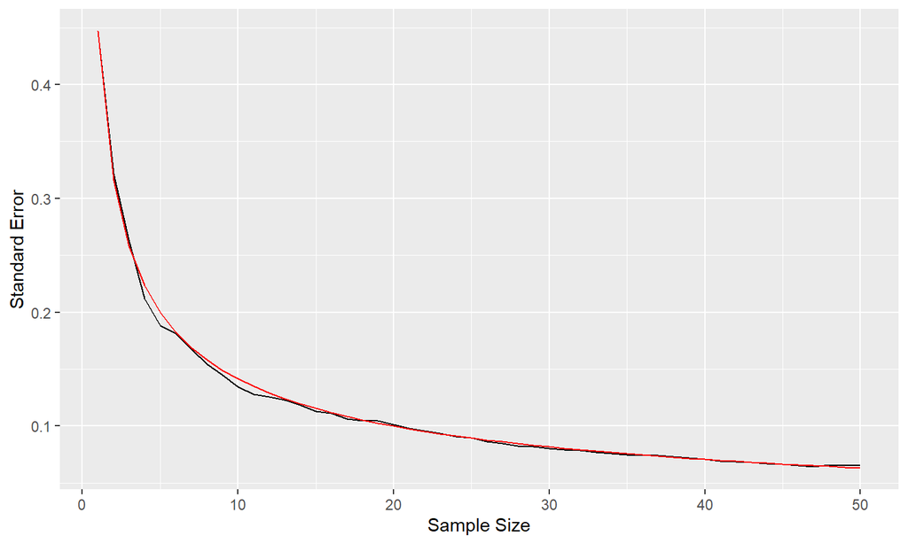

## Discuss

- Describe a study to measure ctenophore species richness in Barkley Sound.
  - Define what the sample unit is, how you might select locations, variables that might influence density and variability.
- Describe a study to measure what temperature does to ctenophore ciliary beat rate?
  - Describe how you might measure this, what the sample unit is, how you might select locations, variables that might influence density and variability.
- Develop a hypothesis about ctenophore and then describe how you might answer it.

## Research Question (Experimental)

- Chat with Gina in the car

## Research Qestion (Observational)

- Chat with Gina in the car